# Quanto vale este imóvel?

Análise exploratória, criação de features e modelos de regressão com tidymodels

Autor

MAT02053 – Estatística Aplicada a Negócios (UFRGS)

# 1 Contexto e setup

## 1.1 O problema de negócio

Imagine que nós somos a **equipe de dados de uma imobiliária**. Os proprietários chegam perguntando sempre a mesma coisa: *“por quanto eu consigo vender a minha casa?”*. Hoje a resposta depende do “feeling” de cada corretor. Nossa missão é construir uma **calculadora de preço**: a pessoa informa as características do imóvel e recebe uma estimativa de preço.

Isso não é ficção: plataformas como o QuintoAndar oferecem exatamente esse tipo de calculadora (“quanto vale meu imóvel?”). Por trás delas existe o que vamos fazer hoje:

1. **Entender os dados** (análise exploratória e visualização);
2. **Criar variáveis úteis** (features);
3. **Treinar e comparar vários modelos** de machine learning;
4. **Usar o melhor modelo** para prever o preço de uma casa nova.

## 1.2 Sobre os dados

Vamos usar a base `Housing.csv` (disponível no Kaggle), com **545 casas vendidas na Índia**. Por isso:

- o **preço** (`price`) está em **rúpias indianas**;
- a **área** (`area`) está em **pés quadrados** (1 pé² ≈ 0,093 m²).

Vamos manter as unidades originais. O raciocínio é exatamente o mesmo que faríamos com reais e metros quadrados.

| Variável | Significado |
| --- | --- |
| `price` | preço de venda (rúpias) — **é o que queremos prever** |
| `area` | área do terreno (pés²) |
| `bedrooms`, `bathrooms` | número de quartos e de banheiros |
| `stories` | número de andares |
| `parking` | vagas de garagem |
| `mainroad` | fica em rua principal? (yes/no) |
| `guestroom` | tem quarto de hóspedes? (yes/no) |
| `basement` | tem porão? (yes/no) |
| `hotwaterheating` | tem aquecimento de água? (yes/no) |
| `airconditioning` | tem ar-condicionado? (yes/no) |
| `prefarea` | fica em área nobre/preferida? (yes/no) |
| `furnishingstatus` | mobília: unfurnished, semi-furnished, furnished |

## 1.3 Um mínimo de R para começar

Se você nunca usou R, estas três ideias bastam para acompanhar a aula:

- **Objetos** guardam coisas. Criamos um objeto com a “setinha” `<-`.
- **Funções** fazem coisas. Elas têm nome e parênteses: `mean(x)`, `round(3.14159, 2)`.
- O **pipe** `|>` passa o resultado da esquerda para a função da direita. Lemos como **“e então”**.

```r
# 1. Contexto e setup ----

# AULA: Quanto vale este imóvel? (MAT02053 - UFRGS)
# Somos a equipe de dados de uma imobiliária e vamos construir uma
# calculadora de preço de casas. Rode o script bloco a bloco (Ctrl + Enter).
# Este arquivo é gerado a partir de aula_housing.qmd (veja o HTML com as explicações).

# Criando um objeto chamado "precos" com quatro valores
precos <- c(100, 250, 300, 150)

# Aplicando uma função ao objeto: a média dos preços
mean(precos)
```

```
[1] 200
```

```r
# O mesmo cálculo usando o pipe: "pegue precos E ENTÃO calcule a média"
precos |> mean()
```

```
[1] 200
```

```r
# Pipes podem ser encadeados: média e então arredondamento com 1 casa
precos |> mean() |> round(1)
```

```
[1] 200
```

## 1.4 Pacotes

Pacotes são “caixas de ferramentas” que estendem o R. O bloco abaixo **instala apenas os pacotes que ainda não estão no seu computador** (isso só precisa acontecer uma vez) e depois os carrega.

```r
# Lista de pacotes usados na aula
pacotes <- c("tidyverse",   # manipulação (dplyr) e gráficos (ggplot2)
             "tidymodels",  # framework de modelagem
             "glmnet",      # regressão regularizada (LASSO)
             "rpart",       # árvore de decisão
             "ranger",      # random forest
             "xgboost")     # gradient boosting

# Quais ainda não estão instalados?
faltando <- pacotes[!sapply(pacotes, requireNamespace, quietly = TRUE)]

# Instala só os que faltam (se não faltar nenhum, não faz nada)
if (length(faltando) > 0) install.packages(faltando)

# Carrega os dois "pacotes-guarda-chuva" (eles carregam os demais por baixo)
library(tidyverse)
library(tidymodels)

# Evita conflitos de nomes de funções iguais em pacotes diferentes
tidymodels_prefer()
```

## 1.5 Lendo os dados

Os dados estão dentro do arquivo `archive.zip`, na pasta do projeto. Conseguimos ler o CSV **direto de dentro do zip**, sem descompactar.

**Importante**

Abra sempre a aula pelo arquivo **`housing_pricing.Rproj`**. Assim o RStudio já “entra” na pasta certa e o R encontra o `archive.zip`.

```r
# Conferindo se estamos na pasta certa antes de ler os dados
if (!file.exists("archive.zip")) {
  stop("Não encontrei o arquivo archive.zip. ",
       "Feche o RStudio e abra o arquivo housing_pricing.Rproj ",
       "(ou use o menu Session > Set Working Directory > Choose Directory ",
       "e escolha a pasta housing_pricing).")
}

# unz() abre um arquivo de dentro do zip; read_csv() lê o CSV
housing_bruto <- read_csv(unz("archive.zip", "Housing.csv"))

# Primeira olhada: quantas linhas e colunas, e o tipo de cada coluna
glimpse(housing_bruto)
```

```
Rows: 545
Columns: 13
$ price            <dbl> 13300000, 12250000, 12250000, 12215000, 11410000, 108…
$ area             <dbl> 7420, 8960, 9960, 7500, 7420, 7500, 8580, 16200, 8100…
$ bedrooms         <dbl> 4, 4, 3, 4, 4, 3, 4, 5, 4, 3, 3, 4, 4, 4, 3, 4, 4, 3,…
$ bathrooms        <dbl> 2, 4, 2, 2, 1, 3, 3, 3, 1, 2, 1, 3, 2, 2, 2, 1, 2, 2,…
$ stories          <dbl> 3, 4, 2, 2, 2, 1, 4, 2, 2, 4, 2, 2, 2, 2, 2, 2, 2, 4,…
$ mainroad         <chr> "yes", "yes", "yes", "yes", "yes", "yes", "yes", "yes…
$ guestroom        <chr> "no", "no", "no", "no", "yes", "no", "no", "no", "yes…
$ basement         <chr> "no", "no", "yes", "yes", "yes", "yes", "no", "no", "…
$ hotwaterheating  <chr> "no", "no", "no", "no", "no", "no", "no", "no", "no",…
$ airconditioning  <chr> "yes", "yes", "no", "yes", "yes", "yes", "yes", "no",…
$ parking          <dbl> 2, 3, 2, 3, 2, 2, 2, 0, 2, 1, 2, 2, 1, 2, 0, 2, 1, 2,…
$ prefarea         <chr> "yes", "no", "yes", "yes", "no", "yes", "yes", "no", …
$ furnishingstatus <chr> "furnished", "furnished", "semi-furnished", "furnishe…
```

As colunas `yes/no` e a mobília vieram como texto (`chr`). Para o R, é melhor tratá-las como **fatores** (`factor`), que é o tipo usado para variáveis **categóricas**. Também definimos a ordem das categorias da mobília, do “menos” para o “mais” mobiliado.

```r
# Colunas do tipo sim/não
colunas_sim_nao <- c("mainroad", "guestroom", "basement",
                     "hotwaterheating", "airconditioning", "prefarea")

housing <- housing_bruto |>
  # across() aplica a mesma transformação em várias colunas de uma vez.
  # \(x) cria uma mini-função: "para cada coluna x, transforme x em fator"
  mutate(across(all_of(colunas_sim_nao), \(x) factor(x, levels = c("no", "yes")))) |>
  mutate(furnishingstatus = factor(furnishingstatus,
                                   levels = c("unfurnished", "semi-furnished", "furnished")))

# Conferindo o resultado: as colunas agora são <fct>
glimpse(housing)
```

```
Rows: 545
Columns: 13
$ price            <dbl> 13300000, 12250000, 12250000, 12215000, 11410000, 108…
$ area             <dbl> 7420, 8960, 9960, 7500, 7420, 7500, 8580, 16200, 8100…
$ bedrooms         <dbl> 4, 4, 3, 4, 4, 3, 4, 5, 4, 3, 3, 4, 4, 4, 3, 4, 4, 3,…
$ bathrooms        <dbl> 2, 4, 2, 2, 1, 3, 3, 3, 1, 2, 1, 3, 2, 2, 2, 1, 2, 2,…
$ stories          <dbl> 3, 4, 2, 2, 2, 1, 4, 2, 2, 4, 2, 2, 2, 2, 2, 2, 2, 4,…
$ mainroad         <fct> yes, yes, yes, yes, yes, yes, yes, yes, yes, yes, yes…
$ guestroom        <fct> no, no, no, no, yes, no, no, no, yes, yes, no, yes, n…
$ basement         <fct> no, no, yes, yes, yes, yes, no, no, yes, no, yes, yes…
$ hotwaterheating  <fct> no, no, no, no, no, no, no, no, no, no, no, yes, no, …
$ airconditioning  <fct> yes, yes, no, yes, yes, yes, yes, no, yes, yes, yes, …
$ parking          <dbl> 2, 3, 2, 3, 2, 2, 2, 0, 2, 1, 2, 2, 1, 2, 0, 2, 1, 2,…
$ prefarea         <fct> yes, no, yes, yes, no, yes, yes, no, yes, yes, yes, n…
$ furnishingstatus <fct> furnished, furnished, semi-furnished, furnished, furn…
```

# 2 Análise exploratória

Antes de qualquer modelo, precisamos **conhecer os dados**. Cada gráfico abaixo responde a uma **pergunta de negócio**. É assim que a análise exploratória deve ser feita: guiada por perguntas, não por “fazer todos os gráficos possíveis”.

Os gráficos são feitos com o **ggplot2**, que constrói um gráfico em camadas:

- `ggplot(dados, aes(x = ..., y = ...))` diz **quais dados** e **quais variáveis** vão em cada eixo;
- `geom_...()` diz **que tipo de desenho** fazer (histograma, pontos, caixas…);
- `labs()` coloca títulos e rótulos.

## 2.1 Um resumo numérico

```r
# 2. Análise exploratória ----

# Resumo de cada coluna: mínimo, quartis, média, máximo (numéricas)
# e contagem por categoria (fatores)
summary(housing)
```

```
     price               area          bedrooms       bathrooms
 Min.   : 1750000   Min.   : 1650   Min.   :1.000   Min.   :1.000
 1st Qu.: 3430000   1st Qu.: 3600   1st Qu.:2.000   1st Qu.:1.000
 Median : 4340000   Median : 4600   Median :3.000   Median :1.000
 Mean   : 4766729   Mean   : 5151   Mean   :2.965   Mean   :1.286
 3rd Qu.: 5740000   3rd Qu.: 6360   3rd Qu.:3.000   3rd Qu.:2.000
 Max.   :13300000   Max.   :16200   Max.   :6.000   Max.   :4.000
    stories      mainroad  guestroom basement  hotwaterheating airconditioning
 Min.   :1.000   no : 77   no :448   no :354   no :520         no :373
 1st Qu.:1.000   yes:468   yes: 97   yes:191   yes: 25         yes:172
 Median :2.000
 Mean   :1.806
 3rd Qu.:2.000
 Max.   :4.000
    parking       prefarea        furnishingstatus
 Min.   :0.0000   no :417   unfurnished   :178
 1st Qu.:0.0000   yes:128   semi-furnished:227
 Median :0.0000             furnished     :140
 Mean   :0.6936
 3rd Qu.:1.0000
 Max.   :3.0000
```

## 2.2 Como os preços se distribuem?

*Pergunta de negócio: a maioria das casas é barata ou cara? Existem casas “fora da curva”?*

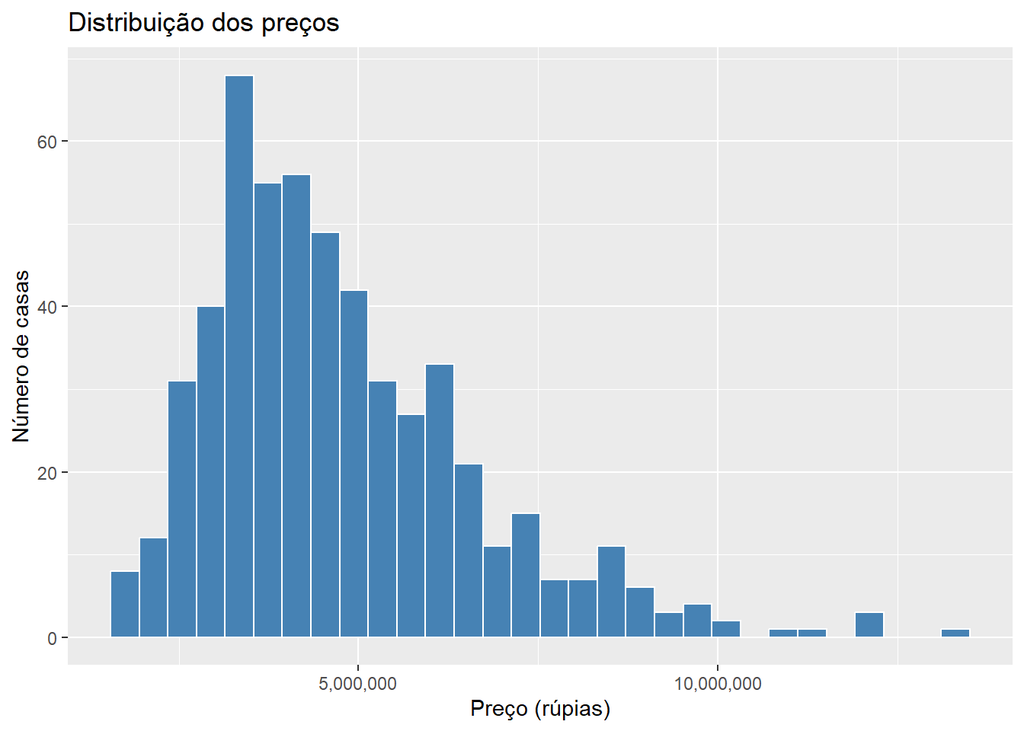

```r
# Histograma: divide os preços em faixas e conta quantas casas há em cada faixa
ggplot(housing, aes(x = price)) +
  geom_histogram(bins = 30, fill = "steelblue", color = "white") +
  scale_x_continuous(labels = scales::label_comma()) +   # números sem notação científica
  labs(title = "Distribuição dos preços",
       x = "Preço (rúpias)", y = "Número de casas")
```

A distribuição é **assimétrica à direita**: muitas casas com preço moderado e poucas casas muito caras, que formam uma “cauda” longa. Isso é muito comum com preços e salários.

Uma transformação muito usada nesses casos é o **logaritmo**. Ele “encolhe” os valores grandes mais do que os pequenos, e a distribuição fica mais simétrica:

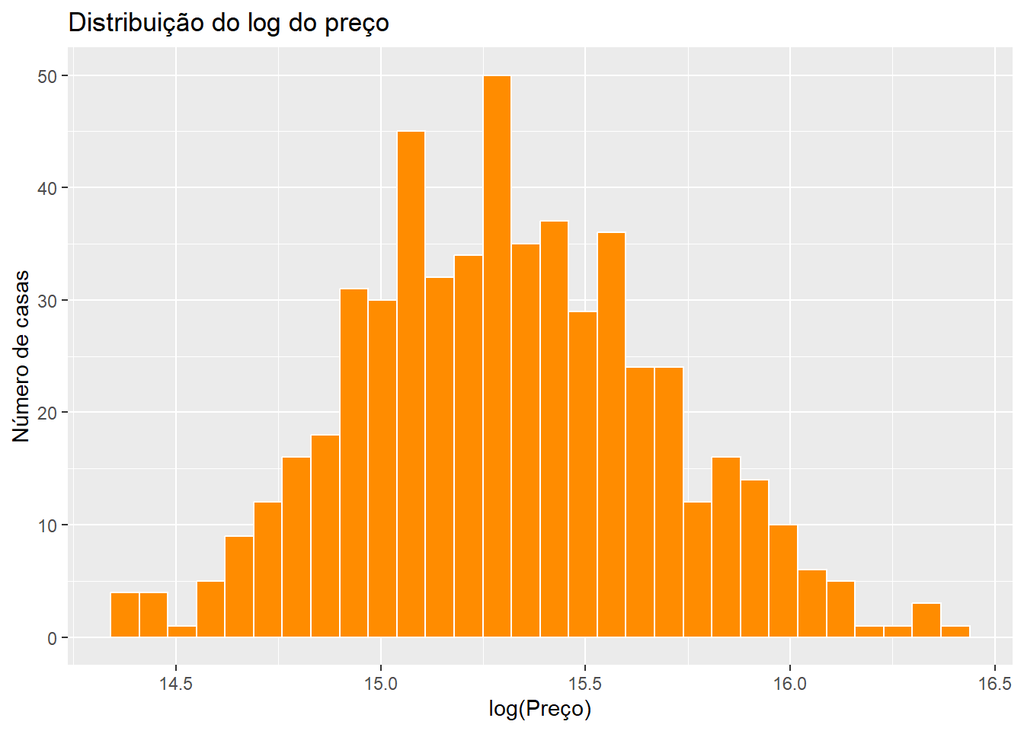

```r
# Mesmo histograma, agora com o log do preço
ggplot(housing, aes(x = log(price))) +
  geom_histogram(bins = 30, fill = "darkorange", color = "white") +
  labs(title = "Distribuição do log do preço",
       x = "log(Preço)", y = "Número de casas")
```

Bem mais simétrica! Por isso **os nossos modelos vão prever o `log(price)`**. No final, voltamos para rúpias com a função inversa do log, a exponencial (`exp()`).

## 2.3 Casas maiores são mais caras?

*Pergunta de negócio: quanto a área influencia o preço?*

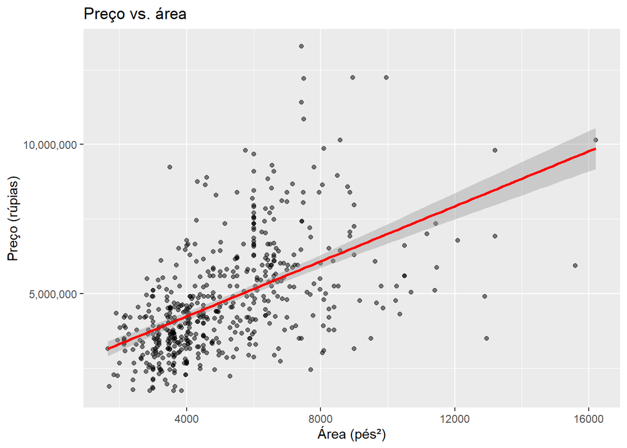

```r
# Gráfico de dispersão: cada ponto é uma casa
ggplot(housing, aes(x = area, y = price)) +
  geom_point(alpha = 0.5) +                          # alpha = transparência
  geom_smooth(method = "lm", color = "red") +        # reta de tendência
  scale_y_continuous(labels = scales::label_comma()) +
  labs(title = "Preço vs. área",
       x = "Área (pés²)", y = "Preço (rúpias)")
```

Existe uma **relação positiva**: casas maiores tendem a custar mais. Porém os pontos estão bem espalhados em volta da reta. **A área sozinha não explica tudo**, e outras características também importam.

## 2.4 Quais comodidades “valorizam” o imóvel?

*Pergunta de negócio: ar-condicionado, área nobre, garagem… o que faz o preço subir?*

O **boxplot** resume uma distribuição: a linha do meio é a **mediana**, a caixa vai do 1º ao 3º quartil (os 50% centrais das casas) e os pontos isolados são valores atípicos.

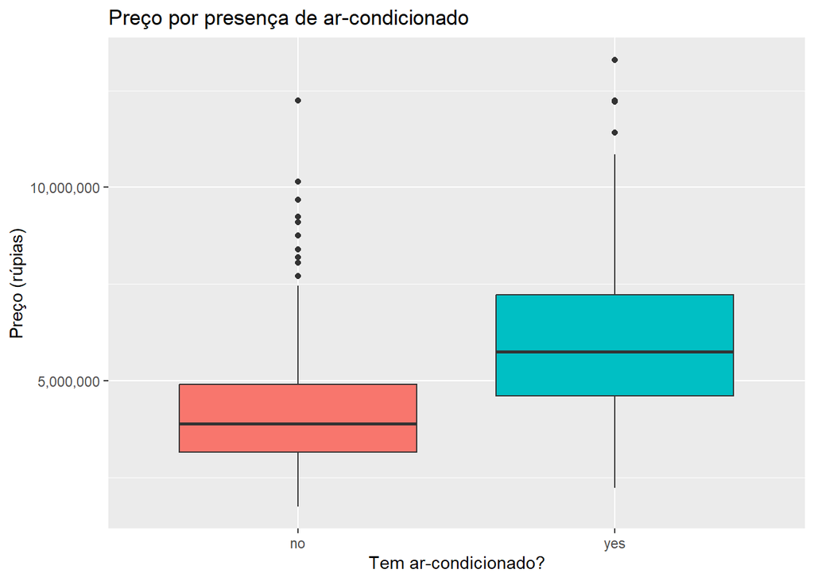

```r
# Boxplot do preço para casas com e sem ar-condicionado
ggplot(housing, aes(x = airconditioning, y = price, fill = airconditioning)) +
  geom_boxplot(show.legend = FALSE) +
  scale_y_continuous(labels = scales::label_comma()) +
  labs(title = "Preço por presença de ar-condicionado",
       x = "Tem ar-condicionado?", y = "Preço (rúpias)")
```

Para comparar **todas as variáveis sim/não de uma vez**, primeiro “empilhamos” essas colunas em formato longo com `pivot_longer()`. Depois desenhamos um painel para cada variável com `facet_wrap()`.

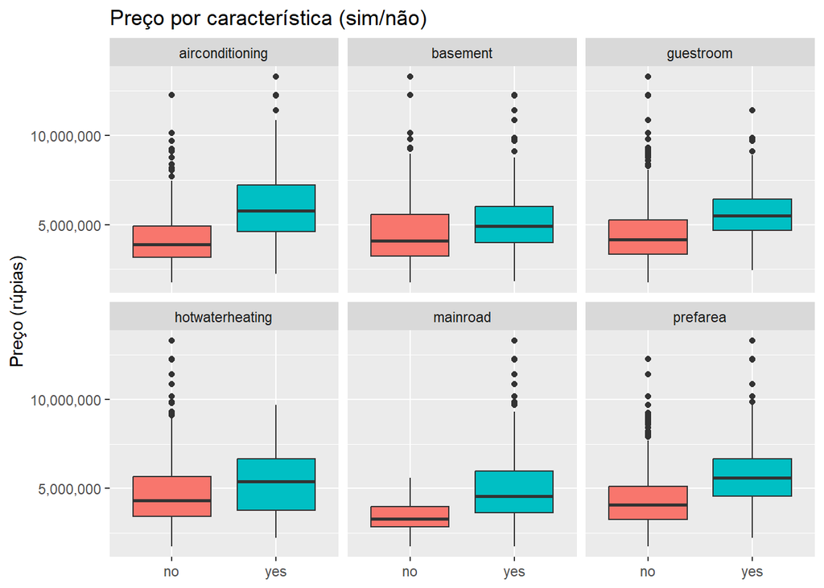

```r
# Boxplots do preço para TODAS as variáveis sim/não, um painel para cada
housing |>
  # Empilha as 6 colunas sim/não em duas: "variavel" (o nome) e "resposta" (yes/no)
  pivot_longer(cols = all_of(colunas_sim_nao),
               names_to = "variavel", values_to = "resposta") |>
  ggplot(aes(x = resposta, y = price, fill = resposta)) +
  geom_boxplot(show.legend = FALSE) +
  facet_wrap(~ variavel, nrow = 2) +                  # um painel por variável
  scale_y_continuous(labels = scales::label_comma()) +
  labs(title = "Preço por característica (sim/não)",
       x = NULL, y = "Preço (rúpias)")
```

Em **todas** as comodidades, as casas com “yes” têm mediana de preço maior. As maiores diferenças aparecem em **ar-condicionado**, **área nobre** (`prefarea`) e **quarto de hóspedes**. Atenção: só 25 casas têm aquecimento de água (`hotwaterheating`), e comparações com grupos tão pequenos são menos confiáveis. A tabela abaixo mostra quantas casas há em cada grupo.

```r
# Quantas casas têm cada comodidade? (ajuda a ler o gráfico anterior)
housing |>
  pivot_longer(cols = all_of(colunas_sim_nao),
               names_to = "variavel", values_to = "resposta") |>
  count(variavel, resposta) |>
  pivot_wider(names_from = resposta, values_from = n)
```

```
# A tibble: 6 × 3
  variavel           no   yes
  <chr>           <int> <int>
1 airconditioning   373   172
2 basement          354   191
3 guestroom         448    97
4 hotwaterheating   520    25
5 mainroad           77   468
6 prefarea          417   128
```

## 2.5 E a mobília?

*Pergunta de negócio: vale a pena vender a casa mobiliada?*

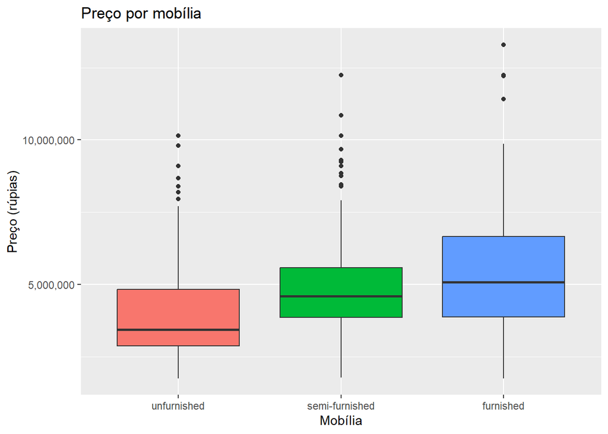

```r
# Boxplot do preço por tipo de mobília
ggplot(housing, aes(x = furnishingstatus, y = price, fill = furnishingstatus)) +
  geom_boxplot(show.legend = FALSE) +
  scale_y_continuous(labels = scales::label_comma()) +
  labs(title = "Preço por mobília",
       x = "Mobília", y = "Preço (rúpias)")
```

Há uma “escada” clara: casas **mobiliadas** têm mediana de preço maior que as **semimobiliadas**, que por sua vez superam as **sem mobília**.

## 2.6 Mais banheiros, mais andares, preço maior?

*Pergunta de negócio: as variáveis de “contagem” se relacionam com o preço?*

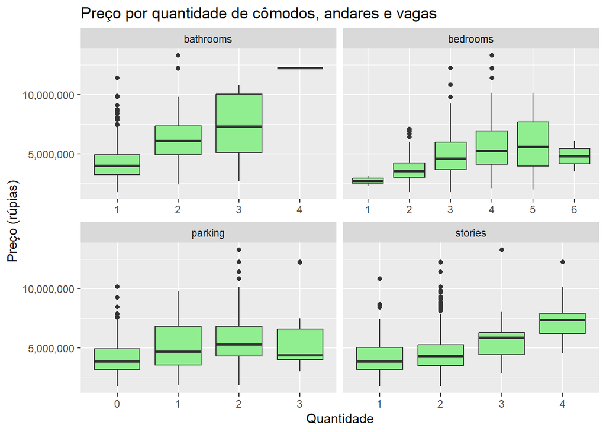

```r
# Boxplots do preço por quantidade de quartos, banheiros, andares e vagas
housing |>
  # Empilha as variáveis de contagem para fazer um painel de cada
  pivot_longer(cols = c(bedrooms, bathrooms, stories, parking),
               names_to = "variavel", values_to = "quantidade") |>
  ggplot(aes(x = factor(quantidade), y = price)) +    # factor(): trata a contagem como categoria
  geom_boxplot(fill = "lightgreen") +
  facet_wrap(~ variavel, scales = "free_x") +
  scale_y_continuous(labels = scales::label_comma()) +
  labs(title = "Preço por quantidade de cômodos, andares e vagas",
       x = "Quantidade", y = "Preço (rúpias)")
```

## 2.7 Quais variáveis numéricas andam juntas?

*Pergunta de negócio: quais características numéricas estão mais associadas ao preço? Há variáveis “repetindo” a mesma informação?*

A **correlação** vai de -1 a 1 e mede o quanto duas variáveis numéricas crescem juntas (positiva) ou em sentidos opostos (negativa), em linha reta.

```r
# Matriz de correlação entre as variáveis numéricas
matriz_cor <- housing |>
  select(where(is.numeric)) |>
  cor()

round(matriz_cor, 2)
```

```
          price area bedrooms bathrooms stories parking
price      1.00 0.54     0.37      0.52    0.42    0.38
area       0.54 1.00     0.15      0.19    0.08    0.35
bedrooms   0.37 0.15     1.00      0.37    0.41    0.14
bathrooms  0.52 0.19     0.37      1.00    0.33    0.18
stories    0.42 0.08     0.41      0.33    1.00    0.05
parking    0.38 0.35     0.14      0.18    0.05    1.00
```

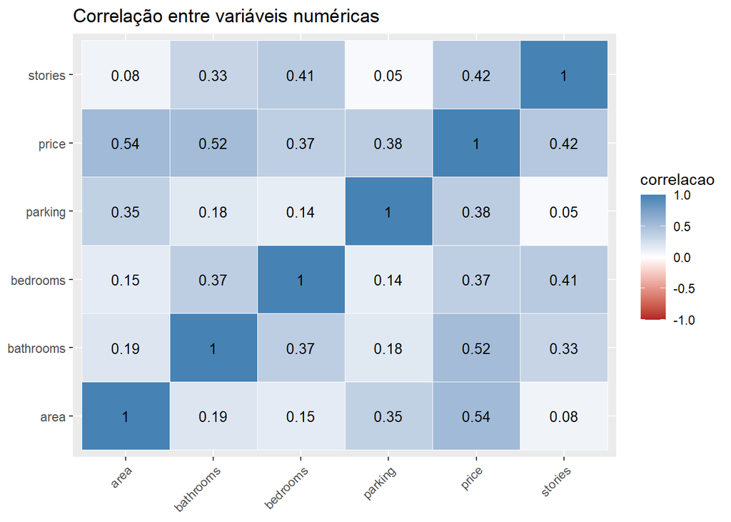

```r
# A mesma matriz em forma de "mapa de calor"
matriz_cor |>
  as_tibble(rownames = "var1") |>
  pivot_longer(-var1, names_to = "var2", values_to = "correlacao") |>
  ggplot(aes(x = var1, y = var2, fill = correlacao)) +
  geom_tile(color = "white") +
  geom_text(aes(label = round(correlacao, 2)), size = 3.5) +
  scale_fill_gradient2(low = "firebrick", mid = "white", high = "steelblue",
                       limits = c(-1, 1)) +
  labs(title = "Correlação entre variáveis numéricas", x = NULL, y = NULL) +
  theme(axis.text.x = element_text(angle = 45, hjust = 1))
```

A **área** e o número de **banheiros** são as variáveis numéricas mais correlacionadas com o preço. Nenhuma correlação entre as explicativas é tão alta a ponto de “uma repetir a outra”.

# 3 Criação de features

**Features** são as variáveis que o modelo usa para prever. Muitas vezes conseguimos **criar features novas** a partir das que já temos, e elas ajudam o modelo a “enxergar” padrões. Essa etapa se chama **feature engineering** e é onde o conhecimento do negócio faz mais diferença.

## 3.1 Criando features “na mão”

Vamos começar com o `mutate()` do dplyr, que cria ou modifica colunas:

- `log_price`: o log do preço, que é **o que vamos prever** (vimos que ele é mais simétrico);
- `log_area`: o log da área, pelo mesmo motivo da assimetria;
- `total_comodos`: quartos + banheiros;
- `n_comodidades`: quantas das 6 comodidades (sim/não) a casa tem. É um “índice de conforto”;
- `preco_pe2`: preço por pé², muito usado no mercado imobiliário.

Vamos guardar essas transformações numa **função**, `criar_features()`. Assim podemos aplicá-las de novo, do mesmo jeito, em qualquer casa: inclusive na casa nova da calculadora, lá no final.

```r
# 3. Criação de features ----

# Uma função recebe "dados" e devolve os dados com as colunas novas
criar_features <- function(dados) {
  dados |>
    mutate(
      log_price     = log(price),
      log_area      = log(area),
      total_comodos = bedrooms + bathrooms,
      # rowSums() soma, linha a linha, quantas colunas sim/não são iguais a "yes"
      n_comodidades = rowSums(across(all_of(colunas_sim_nao), \(x) x == "yes")),
      preco_pe2     = price / area
    )
}

housing_feat <- criar_features(housing)

# Olhando só as colunas novas das primeiras casas
housing_feat |>
  select(price, area, log_price, log_area, total_comodos, n_comodidades, preco_pe2) |>
  head()
```

```
# A tibble: 6 × 7
     price  area log_price log_area total_comodos n_comodidades preco_pe2
     <dbl> <dbl>     <dbl>    <dbl>         <dbl>         <dbl>     <dbl>
1 13300000  7420      16.4     8.91             6             3     1792.
2 12250000  8960      16.3     9.10             8             2     1367.
3 12250000  9960      16.3     9.21             5             3     1230.
4 12215000  7500      16.3     8.92             6             4     1629.
5 11410000  7420      16.3     8.91             5             4     1538.
6 10850000  7500      16.2     8.92             6             4     1447.
```

O índice de comodidades faz sentido para o negócio? Vejamos:

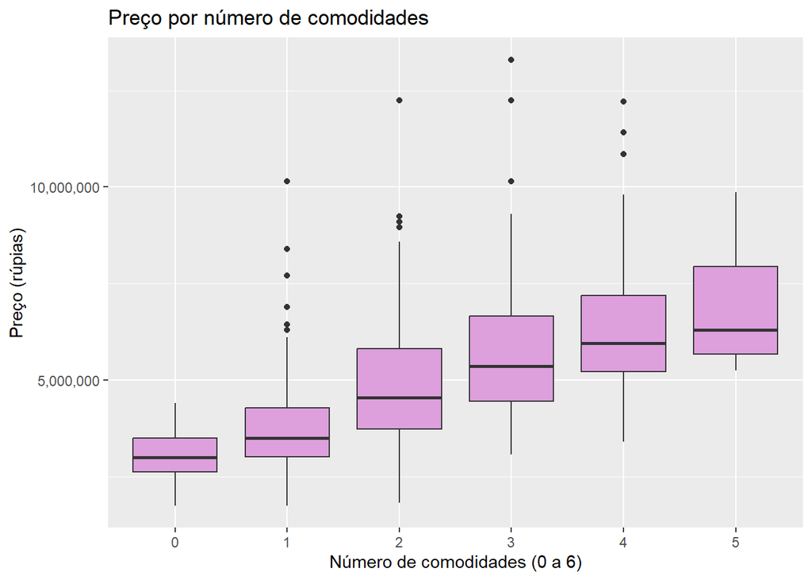

```r
# A feature nova faz sentido? Preço por número de comodidades
ggplot(housing_feat, aes(x = factor(n_comodidades), y = price)) +
  geom_boxplot(fill = "plum") +
  scale_y_continuous(labels = scales::label_comma()) +
  labs(title = "Preço por número de comodidades",
       x = "Número de comodidades (0 a 6)", y = "Preço (rúpias)")
```

Quanto mais comodidades, maior tende a ser o preço. É uma feature simples e útil.

E o preço por pé²? Ele mostra o **valor do “metro quadrado”** em cada região:

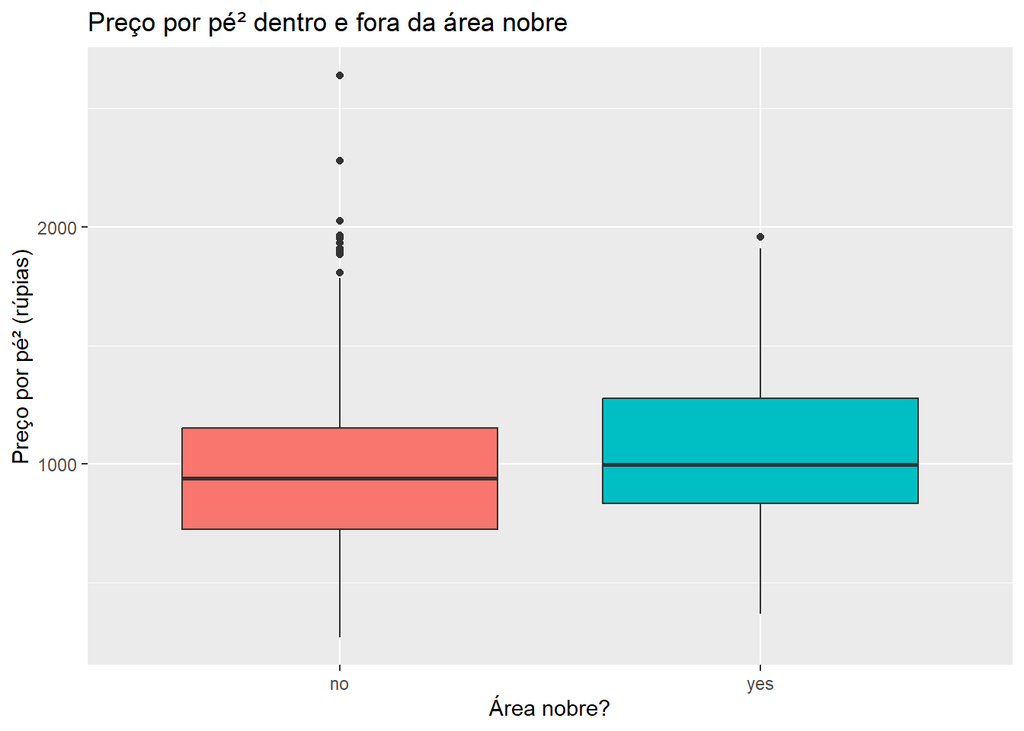

```r
# Preço por pé² (só para explorar: NÃO pode entrar no modelo, pois usa o preço!)
ggplot(housing_feat, aes(x = prefarea, y = preco_pe2, fill = prefarea)) +
  geom_boxplot(show.legend = FALSE) +
  labs(title = "Preço por pé² dentro e fora da área nobre",
       x = "Área nobre?", y = "Preço por pé² (rúpias)")
```

**AvisoCuidado com o vazamento de dados (*data leakage*)**

O `preco_pe2` é ótimo para **explorar** os dados, mas **não pode entrar no modelo**. Ele é calculado com o próprio preço! Na calculadora, a pessoa ainda não sabe o preço da casa, então também não sabe o preço por pé². Usar uma variável que “contém a resposta” deixa o modelo artificialmente perfeito no treino e inútil na prática. Isso se chama **vazamento de dados**.

## 3.2 Separando treino e teste

Para saber se um modelo funciona em casas **que ele nunca viu**, separamos os dados em duas partes:

- **treino (80%)**: usado para ajustar os modelos;
- **teste (20%)**: guardado “no cofre” e usado **uma única vez**, no final, para a avaliação definitiva.

O `set.seed()` fixa o sorteio. Assim todos na sala obtêm exatamente a mesma divisão e os mesmos resultados.

```r
# Separando 80% das casas para treino e 20% para teste
# set.seed() fixa o sorteio: todos obtêm a mesma divisão
set.seed(2026)

# strata = price: garante casas baratas e caras em proporções parecidas nas duas partes
split_housing <- initial_split(housing_feat, prop = 0.8, strata = price)

treino <- training(split_housing)
teste  <- testing(split_housing)

# Quantas casas ficaram em cada parte?
nrow(treino)
```

```
[1] 434
```

```r
nrow(teste)
```

```
[1] 111
```

## 3.3 Validação cruzada

Ainda dentro do treino, queremos **comparar modelos** sem tocar no teste. Para isso usamos a **validação cruzada com 5 *folds***:

1. o treino é dividido em 5 pedaços (*folds*);
2. o modelo é ajustado em 4 pedaços e avaliado no 5º;
3. isso se repete 5 vezes, cada vez deixando um pedaço diferente de fora;
4. a nota final é a **média das 5 avaliações**.

Assim cada modelo recebe uma nota mais estável do que se fosse avaliado uma vez só.

```r
# Validação cruzada: divide o treino em 5 pedaços (folds)
set.seed(2026)
folds <- vfold_cv(treino, v = 5, strata = price)
folds
```

```
#  5-fold cross-validation using stratification
# A tibble: 5 × 2
  splits           id
  <list>           <chr>
1 <split [346/88]> Fold1
2 <split [346/88]> Fold2
3 <split [347/87]> Fold3
4 <split [348/86]> Fold4
5 <split [349/85]> Fold5
```

## 3.4 A receita (*recipe*): features do jeito tidymodels

O `mutate()` foi ótimo para entender as features. Mas há transformações que **aprendem algo com os dados**, como a **normalização** (subtrair a média e dividir pelo desvio-padrão). Essa média e esse desvio-padrão precisam ser calculados **só com o treino**. Se usarmos o teste nesse cálculo, ele “vaza” informação para o modelo.

O tidymodels resolve isso com a **receita** (`recipe`): uma lista de passos de preparação que é **aprendida no treino** e **aplicada igualzinha** em qualquer dado novo (teste, validação cruzada, ou a casa da calculadora).

```r
receita <- recipe(log_price ~ ., data = treino) |>   # prever log_price com todas as outras colunas...
  step_rm(price, preco_pe2) |>                        # ...exceto price e preco_pe2 (vazamento!)
  step_dummy(all_nominal_predictors()) |>             # categorias viram colunas 0/1 (dummies)
  step_normalize(all_numeric_predictors())            # numéricas com média 0 e desvio-padrão 1

# Imprimir a receita mostra a lista de passos
receita
```

[output not shown]

Para ver o que a receita produz, fazemos o `prep()`, que **aprende** (calcula médias, desvios, categorias), e o `bake()`, que **aplica** a receita:

```r
# Só para olhar o resultado da receita (o tidymodels faz isso sozinho ao modelar)
receita |>
  prep() |>                   # aprende os passos usando o treino
  bake(new_data = NULL) |>    # aplica nos próprios dados de treino
  glimpse()
```

```
Rows: 434
Columns: 17
$ area                            <dbl> -0.5443505, -0.6145810, -1.4128684, -1…
$ bedrooms                        <dbl> -1.31746568, 0.05042931, 0.05042931, 0…
$ bathrooms                       <dbl> -0.5638057, -0.5638057, -0.5638057, -0…
$ stories                         <dbl> -0.9262583, -0.9262583, 1.3513400, 0.2…
$ parking                         <dbl> -0.7713315, -0.7713315, -0.7713315, -0…
$ log_area                        <dbl> -0.43775442, -0.53326900, -1.99501450,…
$ total_comodos                   <dbl> -1.2013753, -0.2411601, -0.2411601, -0…
$ n_comodidades                   <dbl> -0.80585300, -0.80585300, 0.04303099, …
$ log_price                       <dbl> 15.04807, 15.04807, 15.04807, 15.04807…
$ mainroad_yes                    <dbl> 0.4192206, 0.4192206, 0.4192206, 0.419…
$ guestroom_yes                   <dbl> -0.4454624, -0.4454624, -0.4454624, -0…
$ basement_yes                    <dbl> -0.7185333, -0.7185333, -0.7185333, 1.…
$ hotwaterheating_yes             <dbl> -0.2195401, -0.2195401, -0.2195401, -0…
$ airconditioning_yes             <dbl> -0.6820132, -0.6820132, -0.6820132, -0…
$ prefarea_yes                    <dbl> -0.5429931, -0.5429931, 1.8374008, 1.8…
$ furnishingstatus_semi.furnished <dbl> -0.8569155, -0.8569155, -0.8569155, -0…
$ furnishingstatus_furnished      <dbl> -0.5926329, -0.5926329, 1.6834971, -0.…
```

Repare que `airconditioning` virou `airconditioning_yes` (0 ou 1, depois normalizado), que a mobília virou duas dummies e que `price` e `preco_pe2` sumiram. **Não precisamos fazer `prep()`/`bake()` manualmente para modelar**: o tidymodels faz isso automaticamente dentro de cada *fold* da validação cruzada. Aqui fizemos só para olhar.

# 4 Modelagem

## 4.1 A lógica do tidymodels

No tidymodels, um modelo é montado como um “lego” com três peças:

1. **o tipo de modelo** (`linear_reg()`, `rand_forest()`…): *que* modelo usar;
2. **o motor** (`set_engine()`): *qual pacote* do R faz as contas;
3. **o modo** (`set_mode()`): *regressão* (prever um número) ou *classificação* (prever uma categoria).

A receita e o modelo se juntam num **workflow** (fluxo de trabalho). Isso garante que a mesma preparação de dados seja sempre aplicada antes do modelo.

## 4.2 Os cinco candidatos

| Modelo | Ideia em uma frase |
| --- | --- |
| **Regressão linear** | o preço (em log) é uma soma ponderada das características |
| **LASSO** | regressão linear que “encolhe” coeficientes pouco úteis até zero, evitando exagero |
| **Árvore de decisão** | uma sequência de perguntas sim/não (“área > 5000?”) que termina num preço |
| **Random forest** | centenas de árvores diferentes “votando”: a previsão é a média delas |
| **XGBoost** | árvores construídas em sequência, cada uma corrigindo os erros das anteriores |

```r
# 4. Modelagem ----

# Modelo 1: Regressão linear
modelo_linear <- linear_reg() |>
  set_engine("lm")

# Modelo 2: LASSO: a "penalty" (quanto encolher) será escolhida por tuning logo abaixo
modelo_lasso <- linear_reg(penalty = tune(), mixture = 1) |>   # mixture = 1 significa LASSO
  set_engine("glmnet")

# Modelo 3: Árvore de decisão com no máximo 5 níveis de perguntas
modelo_arvore <- decision_tree(tree_depth = 5) |>
  set_engine("rpart") |>
  set_mode("regression")

# Modelo 4: Random forest com 500 árvores
modelo_rf <- rand_forest(trees = 500, min_n = 5) |>
  set_engine("ranger", seed = 2026, num.threads = 1) |>   # seed e 1 thread: resultado reprodutível
  set_mode("regression")

# Modelo 5: XGBoost com 300 árvores pequenas e aprendizado lento
modelo_xgb <- boost_tree(trees = 300, learn_rate = 0.05, tree_depth = 3) |>
  set_engine("xgboost", nthread = 1) |>
  set_mode("regression")
```

## 4.3 Um pouquinho de tuning: a penalidade do LASSO

**Hiperparâmetros** são “botões” do modelo que não são aprendidos com os dados: nós escolhemos. No LASSO, o botão principal é a **penalidade**. Com penalidade zero ele é igual à regressão linear; com penalidade grande, ele zera todos os coeficientes.

Para escolher o valor, testamos **10 valores** de penalidade na validação cruzada e ficamos com o que tiver o **menor erro (RMSE)**. Isso é o **tuning**. Nos outros modelos usamos valores fixos razoáveis, para a aula não ficar lenta.

```r
# Tuning: testa 10 valores de penalidade do LASSO na validação cruzada
set.seed(2026)
tuning_lasso <- workflow() |>
  add_recipe(receita) |>
  add_model(modelo_lasso) |>
  tune_grid(resamples = folds, grid = 10)   # 10 valores de penalidade

# Os melhores valores de penalidade segundo o RMSE (em escala log)
show_best(tuning_lasso, metric = "rmse", n = 3)
```

```
# A tibble: 3 × 7
   penalty .metric .estimator  mean     n std_err .config
     <dbl> <chr>   <chr>      <dbl> <int>   <dbl> <chr>
1 7.88e- 3 rmse    standard   0.212     5 0.00640 pre0_mod08_post0
2 1.03e- 3 rmse    standard   0.213     5 0.00667 pre0_mod07_post0
3 1.83e-10 rmse    standard   0.214     5 0.00668 pre0_mod01_post0
```

```r
# Fixando a melhor penalidade no modelo LASSO
melhor_penalidade <- select_best(tuning_lasso, metric = "rmse")
modelo_lasso_final <- finalize_model(modelo_lasso, melhor_penalidade)
modelo_lasso_final
```

```
Linear Regression Model Specification (regression)

Main Arguments:
  penalty = 0.00788146535864697
  mixture = 1

Computational engine: glmnet
```

**DicaApareceu um aviso no console?**

Durante o tuning pode aparecer: *“`estimate` is constant and has 0 standard deviation”*. Nas penalidades muito altas, o LASSO zera todos os coeficientes e prevê **o mesmo preço para todas as casas**. Aí o R² não pode ser calculado. É esperado e não atrapalha: essas penalidades simplesmente perdem a disputa.

## 4.4 Treinando todos os modelos de uma vez

O `workflow_set()` combina a receita com os cinco modelos. O `workflow_map()` roda a **validação cruzada para todos eles**. Usamos `save_pred = TRUE` para guardar as previsões de cada *fold*: vamos precisar delas para calcular os erros em rúpias.

```r
# Junta a receita com os 5 modelos num único "conjunto de workflows"
modelos_wf <- workflow_set(
  preproc = list(receita = receita),
  models  = list(linear = modelo_linear,
                 lasso  = modelo_lasso_final,
                 arvore = modelo_arvore,
                 rf     = modelo_rf,
                 xgb    = modelo_xgb)
)

# Roda a validação cruzada para os 5 modelos (guardando as previsões)
modelos_wf <- modelos_wf |>
  workflow_map("fit_resamples",
               resamples = folds,
               control = control_resamples(save_pred = TRUE),
               seed = 2026)

# Uma linha por modelo, com os resultados dentro
modelos_wf
```

```
# A workflow set/tibble: 5 × 4
  wflow_id       info             option    result
  <chr>          <list>           <list>    <list>
1 receita_linear <tibble [1 × 4]> <opts[2]> <rsmp[+]>
2 receita_lasso  <tibble [1 × 4]> <opts[2]> <rsmp[+]>
3 receita_arvore <tibble [1 × 4]> <opts[2]> <rsmp[+]>
4 receita_rf     <tibble [1 × 4]> <opts[2]> <rsmp[+]>
5 receita_xgb    <tibble [1 × 4]> <opts[2]> <rsmp[+]>
```

**DicaE o aviso *“prediction from rank-deficient fit”*?**

Ele vem da regressão linear e é uma ótima lição de estatística! Criamos `total_comodos = bedrooms + bathrooms`, que é uma **combinação linear exata** de outras duas variáveis (**multicolinearidade perfeita**). A regressão linear não consegue separar o efeito das três, então o R descarta uma delas automaticamente e avisa. O LASSO, por ter penalidade, lida com isso sem reclamar. Moral: nem toda feature nova traz informação nova.

## 4.5 Voltando para rúpias

Os modelos preveem **log(preço)**. Um erro de “0,2 em log” não diz nada para um corretor! Por isso:

1. pegamos as previsões de cada modelo em cada *fold*;
2. aplicamos `exp()` no valor real e no previsto, o que **desfaz o log** e volta para rúpias;
3. calculamos as métricas de erro em rúpias.

```r
# Previsões de cada modelo em cada fold, de volta para rúpias
previsoes_cv <- modelos_wf |>
  collect_predictions(summarize = FALSE) |>
  mutate(preco_real     = exp(log_price),   # exp() desfaz o log
         preco_previsto = exp(.pred))

# Olhando algumas previsões
previsoes_cv |>
  select(wflow_id, id, preco_real, preco_previsto) |>
  head()
```

```
# A tibble: 6 × 4
  wflow_id       id    preco_real preco_previsto
  <chr>          <chr>      <dbl>          <dbl>
1 receita_linear Fold1   3395000.       5729041.
2 receita_linear Fold1   3395000.       3473150.
3 receita_linear Fold1   3360000.       3100442.
4 receita_linear Fold1   3255000        3224876.
5 receita_linear Fold1   3150000.       3090732.
6 receita_linear Fold1   3150000.       2375633.
```

## 4.6 As métricas de qualidade do ajuste

| Métrica | O que mede | Melhor quando |
| --- | --- | --- |
| **RMSE** (raiz do erro quadrático médio) | erro típico em rúpias, **punindo mais os erros grandes** | menor |
| **MAE** (erro absoluto médio) | erro médio em rúpias, todos os erros com o mesmo peso | menor |
| **MAPE** (erro percentual absoluto médio) | erro médio **em %** do preço real | menor |
| **R²** (coeficiente de determinação) | quanto da variação dos preços o modelo acompanha (de 0 a 1) | maior |

O R² também é calculado em rúpias, depois do `exp()`, como as outras métricas. No `yardstick`, a função `rsq()` calcula o **quadrado da correlação** entre o preço real e o previsto. Para um modelo bem calibrado, isso equivale à “proporção da variação explicada”.

Cada métrica conversa com uma preocupação diferente da imobiliária. O **RMSE** importa se errar feio numa casa cara é muito grave. O **MAE** é o “erro típico” que o corretor vai sentir. O **MAPE** trata igualmente casas baratas e caras: errar 10% é errar 10%.

```r
# Conjunto das 4 métricas
metricas <- metric_set(rmse, mae, mape, rsq)

metricas_cv <- previsoes_cv |>
  group_by(wflow_id, id) |>                                   # para cada modelo e cada fold...
  metricas(truth = preco_real, estimate = preco_previsto) |>  # ...calcula as 4 métricas
  group_by(wflow_id, .metric) |>                              # e então, para cada modelo e métrica...
  summarise(mean    = mean(.estimate),                        # ...a média nos 5 folds
            std_err = sd(.estimate) / sqrt(n()),              # ...e o erro-padrão dessa média
            .groups = "drop")

# Tabela comparativa: uma linha por modelo, uma coluna por métrica
metricas_cv |>
  select(-std_err) |>
  pivot_wider(names_from = .metric, values_from = mean) |>
  arrange(rmse)
```

```
# A tibble: 5 × 5
  wflow_id           mae  mape     rmse   rsq
  <chr>            <dbl> <dbl>    <dbl> <dbl>
1 receita_lasso  771549.  16.6 1095660. 0.671
2 receita_linear 785307.  16.8 1109305. 0.661
3 receita_rf     814522.  17.5 1167550. 0.632
4 receita_xgb    851304.  18.2 1202438. 0.603
5 receita_arvore 968146.  20.9 1344067. 0.510
```

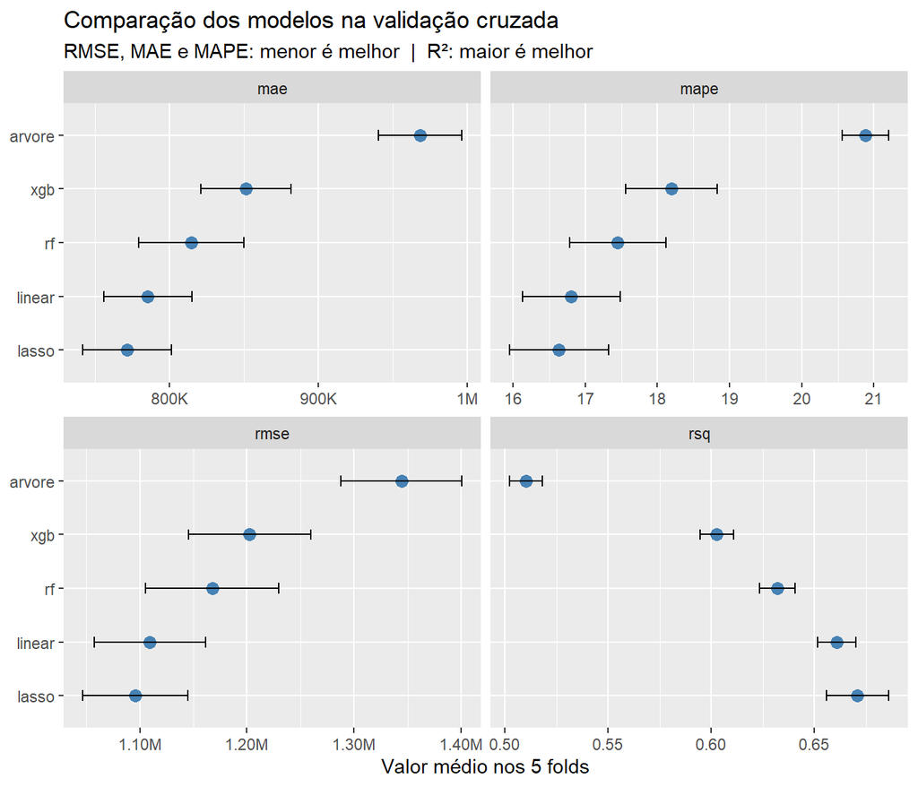

```r
# Gráfico de comparação: ponto = média nos folds; barra = ± 1 erro-padrão
metricas_cv |>
  mutate(modelo = str_remove(wflow_id, "receita_")) |>
  ggplot(aes(x = mean, y = reorder(modelo, mean))) +
  geom_point(size = 3, color = "steelblue") +
  geom_errorbar(aes(xmin = mean - std_err, xmax = mean + std_err), width = 0.2) +
  facet_wrap(~ .metric, scales = "free_x") +
  scale_x_continuous(labels = scales::label_number(scale_cut = scales::cut_short_scale())) +  # 1.2M = 1,2 milhão
  labs(title = "Comparação dos modelos na validação cruzada",
       subtitle = "RMSE, MAE e MAPE: menor é melhor  |  R²: maior é melhor",
       x = "Valor médio nos 5 folds", y = NULL)
```

## 4.7 Quem vence em cada métrica?

```r
# O melhor modelo em cada métrica (média dos 5 folds)
vencedor_por_metrica <- metricas_cv |>
  group_by(.metric) |>
  # para rsq o melhor é o MAIOR; para as outras, o MENOR
  slice_min(if_else(.metric == "rsq", -mean, mean), n = 1) |>
  ungroup() |>
  select(.metric, wflow_id, mean)

vencedor_por_metrica
```

```
# A tibble: 4 × 3
  .metric wflow_id             mean
  <chr>   <chr>               <dbl>
1 mae     receita_lasso  771549.
2 mape    receita_lasso      16.6
3 rmse    receita_lasso 1095660.
4 rsq     receita_lasso       0.671
```

No nosso resultado, o **lasso** ficou em primeiro lugar no RMSE. Antes de declarar um campeão, porém, olhe o **erro-padrão** no gráfico. Quando as barras de dois modelos se sobrepõem, a diferença entre eles é menor que a própria variação entre os *folds*. Na prática, é um **empate técnico**.

## 4.8 O vencedor muda de *fold* para *fold*?

A média esconde a variação. Vamos ver **quem venceu em cada um dos 5 *folds***, para cada métrica:

```r
# Quantos folds cada modelo venceu, em cada métrica?
vencedores_por_fold <- previsoes_cv |>
  group_by(wflow_id, id) |>
  metricas(truth = preco_real, estimate = preco_previsto) |>
  group_by(id, .metric) |>                                         # para cada fold e métrica...
  slice_min(if_else(.metric == "rsq", -.estimate, .estimate), n = 1) |>  # ...o melhor modelo
  ungroup() |>
  count(.metric, wflow_id, name = "folds_vencidos")

vencedores_por_fold |>
  pivot_wider(names_from = .metric, values_from = folds_vencidos, values_fill = 0)
```

```
# A tibble: 3 × 5
  wflow_id         mae  mape  rmse   rsq
  <chr>          <int> <int> <int> <int>
1 receita_lasso      4     3     3     3
2 receita_linear     1     1     2     2
3 receita_rf         0     1     0     0
```

Agora a história fica mais interessante. Dependendo do pedaço dos dados e da **métrica escolhida**, o vencedor muda. As métricas olham o erro de jeitos diferentes:

- o **RMSE** eleva os erros ao quadrado, então **um erro enorme numa mansão pesa muito**;
- o **MAE** trata todos os erros em rúpias igualmente;
- o **MAPE** mede erro **em porcentagem**, então errar 500 mil numa casa barata pesa mais do que errar 500 mil numa casa cara.

Um modelo que acerta bem as casas caras pode se dar melhor no RMSE. Um que acerta bem as casas baratas pode se dar melhor no MAPE. **Escolher a métrica é uma decisão de negócio**: qual tipo de erro custa mais caro para a imobiliária?

**NotaPor que os modelos mais “simples” foram tão bem?**

Com apenas 545 casas e uma relação aproximadamente linear entre as características e o **log** do preço, modelos lineares costumam ir muito bem. Random forest e XGBoost brilham quando há **muitos dados** e **relações complexas**. Mais complexo **não** é sinônimo de melhor!

# 5 Fechamento

## 5.1 A prova final: o conjunto de teste

Escolhemos o modelo vencedor no **RMSE** da validação cruzada. Agora, pela primeira vez, abrimos o “cofre”: o `last_fit()` **ajusta o modelo com todo o treino** e **avalia no teste**, nas casas que nenhum modelo viu até aqui.

```r
# 5. Fechamento ----

# Nome do modelo vencedor no RMSE
vencedor_rmse <- vencedor_por_metrica |>
  filter(.metric == "rmse") |>
  pull(wflow_id)

vencedor_rmse
```

```
[1] "receita_lasso"
```

```r
# Ajuste final: treina no treino completo e avalia no teste
ajuste_final <- modelos_wf |>
  extract_workflow(vencedor_rmse) |>
  last_fit(split_housing)

# Previsões no teste, de volta para rúpias
previsoes_teste <- ajuste_final |>
  collect_predictions() |>
  mutate(preco_real     = exp(log_price),
         preco_previsto = exp(.pred))

# As mesmas 4 métricas, agora no teste
metricas_teste <- previsoes_teste |>
  metricas(truth = preco_real, estimate = preco_previsto)

metricas_teste
```

```
# A tibble: 4 × 3
  .metric .estimator  .estimate
  <chr>   <chr>           <dbl>
1 rmse    standard   938447.
2 mae     standard   713857.
3 mape    standard       15.8
4 rsq     standard        0.715
```

Se as métricas do teste ficarem **parecidas** com as da validação cruzada, é um bom sinal: o modelo **generaliza** para casas novas e não apenas “decorou” o treino.

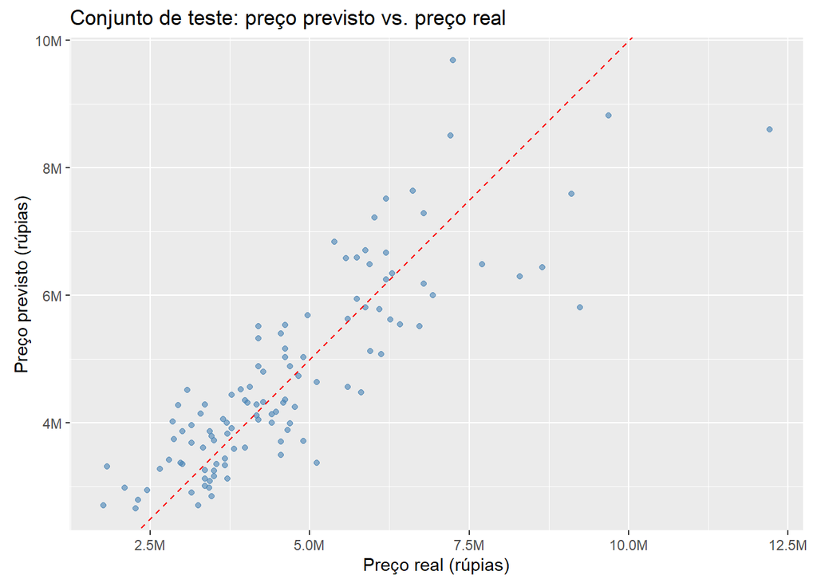

```r
# Previsto vs. real: quanto mais perto da linha tracejada, melhor
ggplot(previsoes_teste, aes(x = preco_real, y = preco_previsto)) +
  geom_point(alpha = 0.6, color = "steelblue") +
  geom_abline(linetype = "dashed", color = "red") +   # linha de 45°: previsão perfeita
  scale_x_continuous(labels = scales::label_number(scale_cut = scales::cut_short_scale())) +
  scale_y_continuous(labels = scales::label_number(scale_cut = scales::cut_short_scale())) +
  coord_equal() +
  labs(title = "Conjunto de teste: preço previsto vs. preço real",
       x = "Preço real (rúpias)", y = "Preço previsto (rúpias)")
```

Repare que o modelo erra mais nas casas **muito caras**. Elas são raras nos dados, então o modelo tem pouca informação sobre elas.

## 5.2 Quais características mais pesam no preço?

Vamos medir a importância de cada característica com uma ideia simples, a **importância por permutação**:

1. calculamos o erro (RMSE) do modelo no teste;
2. **embaralhamos** uma coluna, por exemplo `area`, destruindo a relação dela com o preço;
3. calculamos o erro de novo. **Quanto mais o erro piorar, mais importante era aquela coluna.**

Essa ideia funciona para **qualquer** modelo, seja ele linear, árvore ou floresta.

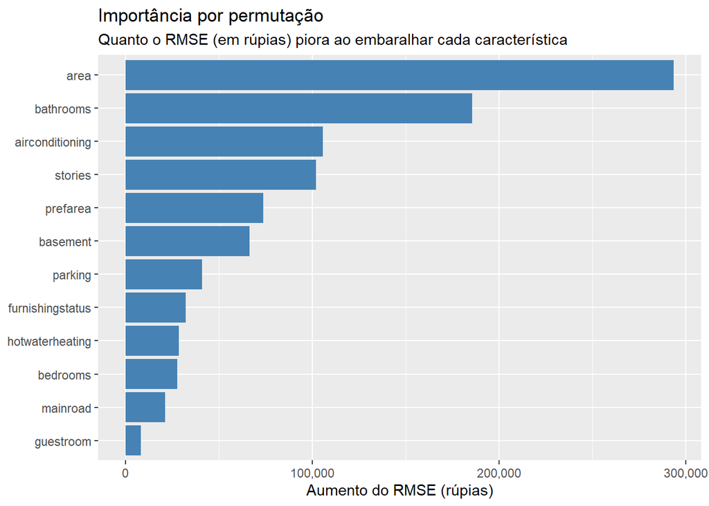

```r
# O modelo final já treinado
modelo_final <- extract_workflow(ajuste_final)

# Teste só com as colunas originais (as features são recalculadas depois)
teste_original <- teste |> select(all_of(names(housing)))

# Função: RMSE (em rúpias) do modelo final num conjunto de dados
rmse_rupias <- function(dados) {
  dados_feat <- criar_features(dados)
  previsto <- exp(predict(modelo_final, dados_feat)$.pred)
  rmse_vec(truth = dados$price, estimate = previsto)
}

rmse_original <- rmse_rupias(teste_original)

# Para cada característica: embaralha 10 vezes e mede o aumento médio do erro
caracteristicas <- setdiff(names(housing), "price")

set.seed(2026)
importancia <- map_dfr(caracteristicas, \(variavel) {
  aumentos <- replicate(10, {
    embaralhado <- teste_original
    embaralhado[[variavel]] <- sample(embaralhado[[variavel]])   # embaralha a coluna
    rmse_rupias(embaralhado) - rmse_original
  })
  tibble(variavel = variavel, aumento_rmse = mean(aumentos))
})

importancia |>
  ggplot(aes(x = aumento_rmse, y = reorder(variavel, aumento_rmse))) +
  geom_col(fill = "steelblue") +
  scale_x_continuous(labels = scales::label_comma()) +
  labs(title = "Importância por permutação",
       subtitle = "Quanto o RMSE (em rúpias) piora ao embaralhar cada característica",
       x = "Aumento do RMSE (rúpias)", y = NULL)
```

O resultado conversa com o que vimos na análise exploratória: **área** e **banheiros** lideram, seguidos de **ar-condicionado**, **número de andares** e **área nobre**. É um bom sinal quando o modelo “aprende” relações que fazem sentido para o negócio.

## 5.3 A calculadora de preço

Chegamos ao produto final! Um proprietário descreve a casa dele, e o modelo responde **quanto ela vale**. Experimente mudar as características abaixo (área, ar-condicionado, área nobre…) e veja como o preço estimado muda.

Para não repetir código, guardamos todo o processo numa **função** `prever_preco()`. Ela confere se as características foram digitadas corretamente, faz as mesmas conversões dos dados originais, cria as features e devolve o preço em rúpias.

```r
# Função da calculadora: recebe a descrição da casa e devolve o preço em rúpias
prever_preco <- function(casa) {
  # 1. Conferindo a digitação (um "Yes" com maiúscula viraria NA sem aviso!)
  for (coluna in colunas_sim_nao) {
    if (!casa[[coluna]] %in% c("yes", "no")) {
      stop("A característica '", coluna, "' foi digitada errado: use \"yes\" ou \"no\".")
    }
  }
  if (!casa$furnishingstatus %in% levels(housing$furnishingstatus)) {
    stop("A característica 'furnishingstatus' foi digitada errado: use ",
         "\"unfurnished\", \"semi-furnished\" ou \"furnished\".")
  }

  # 2. Mesmas conversões que fizemos nos dados originais
  casa_preparada <- casa |>
    mutate(across(all_of(colunas_sim_nao), \(x) factor(x, levels = c("no", "yes"))),
           furnishingstatus = factor(furnishingstatus, levels = levels(housing$furnishingstatus)),
           price = NA_real_) |>   # o preço é desconhecido: é o que queremos descobrir!
    criar_features()

  # 3. Previsão em log e então exp() para voltar a rúpias
  exp(predict(modelo_final, casa_preparada)$.pred)
}
```

Agora é só descrever a casa e chamar a função:

```r
# A casa do proprietário: preencha TODAS as características
casa_digitada <- tibble(
  area             = 6000,              # pés²
  bedrooms         = 3,
  bathrooms        = 2,
  stories          = 2,                 # andares
  parking          = 1,                 # vagas de garagem
  mainroad         = "yes",             # "yes" ou "no"
  guestroom        = "no",              # "yes" ou "no"
  basement         = "yes",             # "yes" ou "no"
  hotwaterheating  = "no",              # "yes" ou "no"
  airconditioning  = "yes",             # "yes" ou "no"
  prefarea         = "no",              # "yes" ou "no"
  furnishingstatus = "semi-furnished"   # "unfurnished", "semi-furnished" ou "furnished"
)

preco_previsto <- prever_preco(casa_digitada)

cat("Preço estimado:", scales::comma(preco_previsto), "rúpias\n")
```

```
Preço estimado: 6,514,406 rúpias
```

Uma boa calculadora também informa **o tamanho típico do erro**. O MAPE do teste diz que, em média, o modelo erra cerca de **16%** do preço real. Podemos mostrar ao proprietário uma faixa de ± MAPE em volta da estimativa:

```r
# Faixa de ± MAPE em volta do preço estimado
mape_teste <- metricas_teste |> filter(.metric == "mape") |> pull(.estimate)

cat("Faixa de ± erro típico:",
    scales::comma(preco_previsto * (1 - mape_teste / 100)), "a",
    scales::comma(preco_previsto * (1 + mape_teste / 100)), "rúpias\n")
```

```
Faixa de ± erro típico: 5,487,562 a 7,541,249 rúpias
```

```r
# Mas atenção: quantas casas do teste realmente caíram dentro de ± MAPE da sua previsão?
cobertura_faixa <- previsoes_teste |>
  summarise(dentro = mean(abs(preco_real - preco_previsto) / preco_real <= mape_teste / 100)) |>
  pull(dentro)

cat("Casas do teste dentro da faixa:", scales::percent(cobertura_faixa), "\n")
```

```
Casas do teste dentro da faixa: 59%
```

**AvisoErro médio não é intervalo de confiança**

O MAPE é um **erro médio**, não uma garantia. No nosso teste, apenas **59%** das casas ficaram dentro de ± MAPE da previsão. As demais erraram mais do que isso. Para uma faixa com cobertura conhecida (por exemplo, 80% ou 95% das casas), seriam necessárias técnicas próprias, como **intervalos de predição** ou *conformal prediction*. Esse é um ótimo próximo passo para uma calculadora de verdade!

## 5.4 Resumo da aula

1. **Análise exploratória**: o preço é assimétrico (por isso usamos log), e área, banheiros, ar-condicionado e área nobre se associam a preços maiores.
2. **Features**: criamos variáveis novas, aprendemos a evitar **vazamento de dados** (`preco_pe2`) e usamos a **receita** para preparar os dados de forma segura.
3. **Modelagem**: comparamos 5 modelos com validação cruzada e 4 métricas. **O “melhor modelo” depende da métrica e da variação entre os folds**, e modelos simples podem vencer os complexos.
4. **Produto**: avaliamos o vencedor no teste e construímos uma calculadora de preço, deixando claro o tamanho típico do erro e seus limites.